# Confidence Intervals

#### Interval estimate

interal is calculated bsed on sample (centered at $\bar(X)_n$) thus it is random. example interval $[\bar{X}_n - 3.2, \bar{X}_n + 3.2]$. If we draw 100 samples 97 will cover the *true mean*

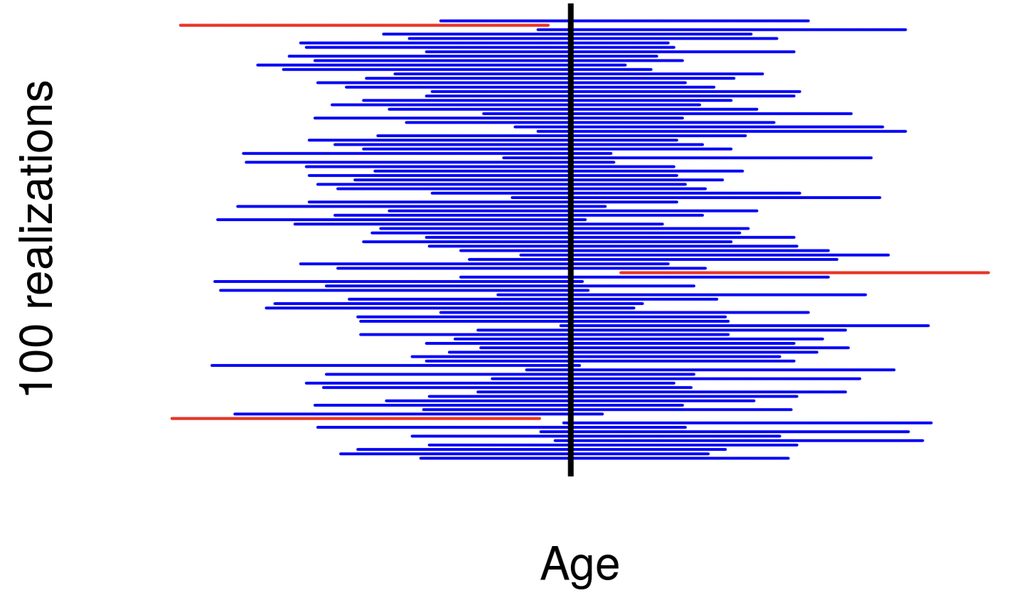

If we reeuce the interval we will reduce our confidence unless we increse samples

[figure not shown]

## Normal t

### Central Limit Theorem

$$\bar X_n \approx N(\mu, \dfrac{\sigma}{\sqrt{n}})$$
where $\sigma$ and $\mu$ are the standard deviation and mean of the population. and $n$ is typically $\geq 30$

**RULE OF THUMB** if $n\hat{p}_n \geq 10 \text{ and } n(1 - \hat p_n) \geq 10$ $\hat p_n \approx N(p, \sqrt{p(1-p)/n))}$

### back to Confidence Intervals

> Can we choose the width to get a desired confidence level?

We want to choose $w$ so that $P(\bar X_n - w \leq \mu \leq \bar X_n + w) = 0.95$

if we only kew the distribution of $\bar X_n$ then $P(\mu - \frac{2 \sigma}{\sqrt{n}} \leq \bar X_n \leq \mu - \frac{2 \sigma}{\sqrt{n}})$. Keep in mind that the true population variance is unknown.

we can also look at the compliment of the confidence level which we will call $\alpha$ such that confidence level = $(1 - \alpha)$ This is called *significance*

```r
qnorm(0.025) # z score at which 2.5% of the population is below
```

```
[1] -1.959964
```

P(1.24 ≤ μ ≤ 5.52)≈ 99% THIS IS NOT TRUE. Without the random variable this is either true or not. What you should say is:

$$P(\bar X_n - \dfrac{2.58 \sigma}{\sqrt n} \leq \mu \leq \bar X_n + \dfrac{2.58 \sigma}{\sqrt n})$$

### When can we treat sample mean as normal

1. When CLT applies (n > 30)

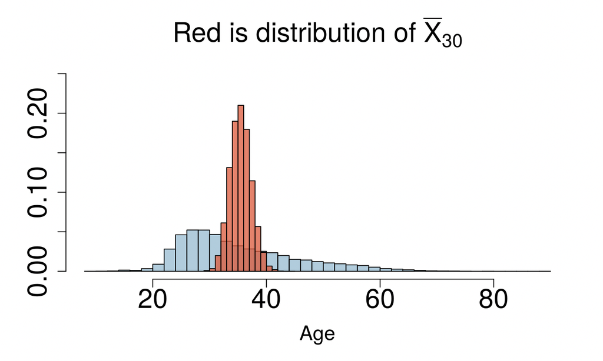

2. When data distribution is itself nearly noraml

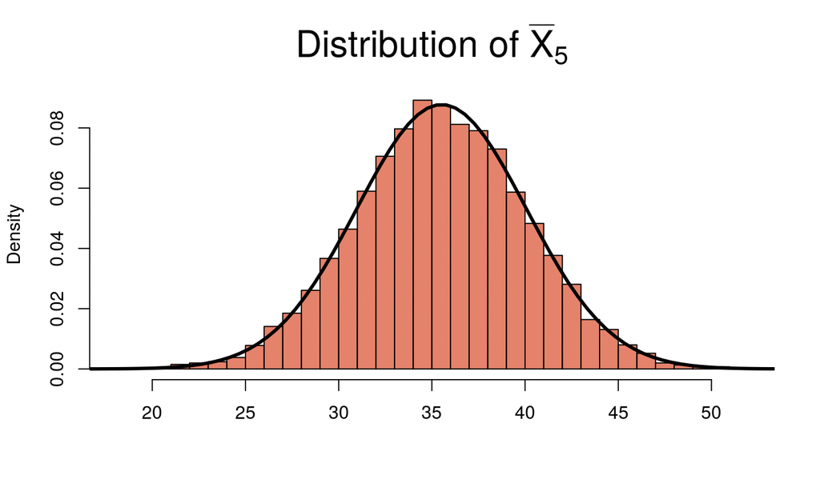

**What happens if $\sigma$ is not known.** Could we replace $\sigma$ by $S_n$ which works if $n$ is large. keep in mind that

$$\dfrac{\bar X_n - \mu}{\frac{S_n}{\sqrt n} } \not\approx N(0,1) \qquad \text{let's call this } T_n$$

using Sample SD has more variance

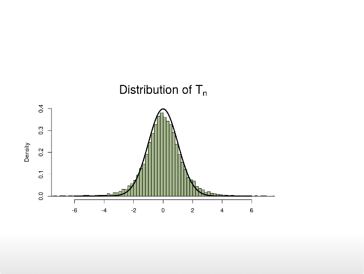

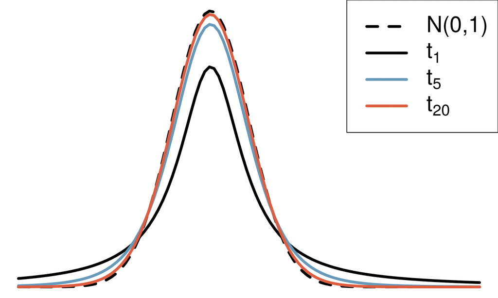

## T distribution

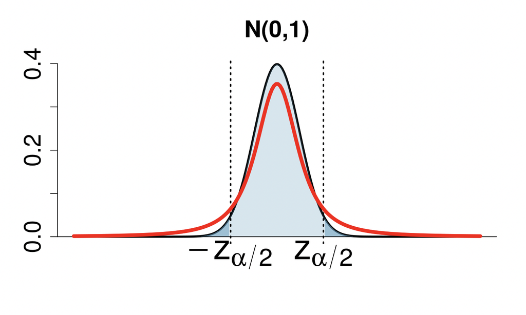

## Recap: t-distribution for a CI

1. Use the t-dist when
- observations are independent
- data’s distribution is nearly nomral
- $\sigma$ is unknown
2. when $n$ is large